# Lab3_Bismi_Poulose_8981107

## LAB 3

### Student Name : Bismi Poulose

### Student ID : 8981107

## 1. Obtain the Data: Get the Dogs vs Cats dataset (see class' notebook, only 5000, not 25,000, images are required, these image set is defined in the notebook)

```python
import os
import shutil

# Source folders
original_train_dir = r"C:\BISMI\COURSE\AI\Fundamental_ML_Programming_new\Assignments\Lab3\archive (6)\train\train"
original_test_dir = r"C:\BISMI\COURSE\AI\Fundamental_ML_Programming_new\Assignments\Lab3\archive (6)\test\test"

# Creating new small dataset folder
base_dir = './data_small'
train_dir = os.path.join(base_dir, 'train')
cat_dir = os.path.join(train_dir, 'cats')
dog_dir = os.path.join(train_dir, 'dogs')

if not os.path.exists(base_dir):
    os.makedirs(cat_dir)
    os.makedirs(dog_dir)

    cat_images = [f for f in os.listdir(original_train_dir) if f.startswith('cat')][:2500]
    dog_images = [f for f in os.listdir(original_train_dir) if f.startswith('dog')][:2500]

    for fname in cat_images:
        shutil.copy(os.path.join(original_train_dir, fname), os.path.join(cat_dir, fname))

    for fname in dog_images:
        shutil.copy(os.path.join(original_train_dir, fname), os.path.join(dog_dir, fname))
```

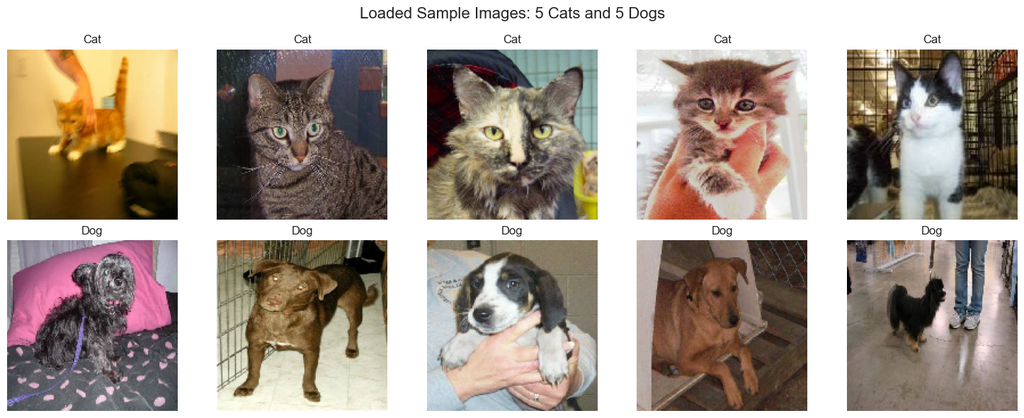

```python
import matplotlib.pyplot as plt
from tensorflow.keras.utils import load_img
import os

# Paths to 5 cat and 5 dog images to print the answers
sample_cat_imgs = os.listdir(cat_dir)[:5]
sample_dog_imgs = os.listdir(dog_dir)[:5]

fig, axs = plt.subplots(2, 5, figsize=(15, 6))
for i, fname in enumerate(sample_cat_imgs + sample_dog_imgs):
    img_path = os.path.join(cat_dir if i < 5 else dog_dir, fname)
    img = load_img(img_path, target_size=(150, 150))
    axs[i // 5, i % 5].imshow(img)
    axs[i // 5, i % 5].axis('off')
    axs[i // 5, i % 5].set_title("Cat" if i < 5 else "Dog")

plt.suptitle("Loaded Sample Images: 5 Cats and 5 Dogs", fontsize=16)
plt.tight_layout()
plt.show()
```

### 2. EDA: Explore the data with relevant graphs, statistics and insights (5 points)

```python
!pip install seaborn
```

[output not shown]

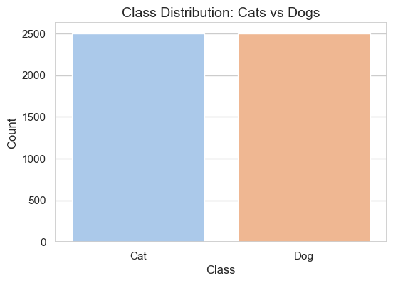

```
Class Count:
 Number of Cat images: 2500
 Number of Dog images: 2500

Sample Image Shape: (374, 500, 3)
-Image Mode: RGB

Image Size Stats (on 100 images):
- Average width: 403.75
- Average height: 364.13
```

```python
import matplotlib.pyplot as plt
import seaborn as sns
import numpy as np
from PIL import Image
import os
import warnings
warnings.filterwarnings("ignore")  # Suppress warnings

# Paths
cat_images = os.listdir(cat_dir)
dog_images = os.listdir(dog_dir)

# 1. Class distribution
labels = ['Cat'] * len(cat_images) + ['Dog'] * len(dog_images)
sns.set(style="whitegrid")
plt.figure(figsize=(6, 4))
sns.countplot(x=labels, palette="pastel")
plt.title("Class Distribution: Cats vs Dogs", fontsize=14)
plt.ylabel("Count")
plt.xlabel("Class")
plt.show()

print("Class Count:")
print(f" Number of Cat images: {len(cat_images)}")
print(f" Number of Dog images: {len(dog_images)}")

# 2. Image size statistics
cat_sample_path = os.path.join(cat_dir, cat_images[0])
img = Image.open(cat_sample_path)
img_array = np.array(img)

print(f"\nSample Image Shape: {img_array.shape}")
print(f"-Image Mode: {img.mode}")

# Checking the average size across a few images
sizes = []
for fname in cat_images[:50] + dog_images[:50]:
    path = os.path.join(cat_dir if 'cat' in fname else dog_dir, fname)
    with Image.open(path) as img:
        sizes.append(img.size)

widths, heights = zip(*sizes)
print("\nImage Size Stats (on 100 images):")
print(f"- Average width: {np.mean(widths):.2f}")
print(f"- Average height: {np.mean(heights):.2f}")
```

### 3. Train two networks (use callbacks to save the best model version):

### 1. Define a Neural Network of your choice (3 points)

```python
from tensorflow.keras.preprocessing.image import ImageDataGenerator

# Using the already resized data folder: './data_small/train'
IMG_SIZE = (150, 150)
BATCH_SIZE = 32

datagen = ImageDataGenerator(rescale=1./255, validation_split=0.2)

train_generator = datagen.flow_from_directory(
    './data_small/train',
    target_size=IMG_SIZE,
    batch_size=BATCH_SIZE,
    class_mode='binary',
    subset='training',
    shuffle=True
)

val_generator = datagen.flow_from_directory(
    './data_small/train',
    target_size=IMG_SIZE,
    batch_size=BATCH_SIZE,
    class_mode='binary',
    subset='validation',
    shuffle=False
)
```

```
Found 4000 images belonging to 2 classes.
Found 1000 images belonging to 2 classes.
```

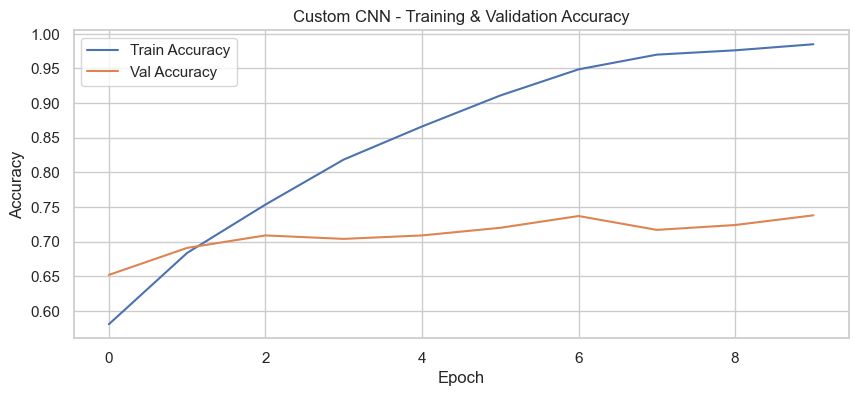

```
3.1 Custom CNN model trained. Best version saved as 'cnn_best_model.h5'.
```

```python
from tensorflow.keras.models import Sequential
from tensorflow.keras.layers import Conv2D, MaxPooling2D, Flatten, Dense, Dropout
from tensorflow.keras.callbacks import ModelCheckpoint
import matplotlib.pyplot as plt

# Defining model
cnn_model = Sequential([
    Conv2D(32, (3, 3), activation='relu', input_shape=(150, 150, 3)),
    MaxPooling2D(2, 2),
    Conv2D(64, (3, 3), activation='relu'),
    MaxPooling2D(2, 2),
    Flatten(),
    Dense(128, activation='relu'),
    Dropout(0.5),
    Dense(1, activation='sigmoid')
])

cnn_model.compile(optimizer='adam', loss='binary_crossentropy', metrics=['accuracy'])

# Save best model
checkpoint_cnn = ModelCheckpoint("cnn_best_model.h5", save_best_only=True, monitor='val_accuracy', mode='max')

# Train
cnn_history = cnn_model.fit(
    train_generator,
    epochs=10,
    validation_data=val_generator,
    callbacks=[checkpoint_cnn]
)

# Plot training history
plt.figure(figsize=(10, 4))
plt.plot(cnn_history.history['accuracy'], label='Train Accuracy')
plt.plot(cnn_history.history['val_accuracy'], label='Val Accuracy')
plt.title('Custom CNN - Training & Validation Accuracy')
plt.xlabel('Epoch')
plt.ylabel('Accuracy')
plt.legend()
plt.grid(True)
plt.show()

print("3.1 Custom CNN model trained. Best version saved as 'cnn_best_model.h5'.")
```

### 2.Fine-Tune VGG16 (pre-trained on imagenet). Make sure to use validation to test for over-fitting. Plot the appropriate graph (3 points)

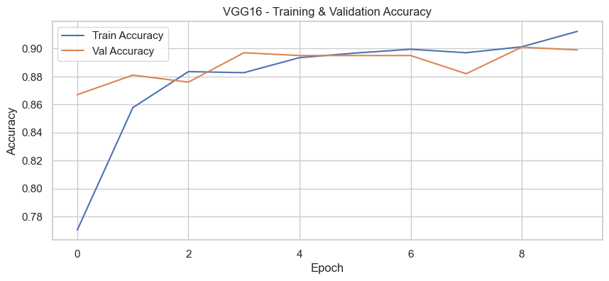

```
3.2 Fine-tuned VGG16 model trained. Best version saved as 'vgg_best_model.h5'.
```

```python
from tensorflow.keras.applications import VGG16
from tensorflow.keras.layers import GlobalAveragePooling2D

# Loading VGG16 base
base_vgg = VGG16(include_top=False, input_shape=(150, 150, 3), weights='imagenet')
base_vgg.trainable = False  # Freeze base

# Adding custom head
vgg_model = Sequential([
    base_vgg,
    GlobalAveragePooling2D(),
    Dense(128, activation='relu'),
    Dropout(0.5),
    Dense(1, activation='sigmoid')
])

vgg_model.compile(optimizer='adam', loss='binary_crossentropy', metrics=['accuracy'])

# Save best VGG16 version
checkpoint_vgg = ModelCheckpoint("vgg_best_model.h5", save_best_only=True, monitor='val_accuracy', mode='max')

# Train
vgg_history = vgg_model.fit(
    train_generator,
    epochs=10,
    validation_data=val_generator,
    callbacks=[checkpoint_vgg]
)

# Plot training history
plt.figure(figsize=(10, 4))
plt.plot(vgg_history.history['accuracy'], label='Train Accuracy')
plt.plot(vgg_history.history['val_accuracy'], label='Val Accuracy')
plt.title('VGG16 - Training & Validation Accuracy')
plt.xlabel('Epoch')
plt.ylabel('Accuracy')
plt.legend()
plt.grid(True)
plt.show()

print("3.2 Fine-tuned VGG16 model trained. Best version saved as 'vgg_best_model.h5'.")
```

### 4. Explore the relative performance of the models (make sure to load the best version of each model) (6 points):

### 4.1. accuracy

```python
from sklearn.metrics import classification_report, confusion_matrix, precision_recall_curve, average_precision_score
import numpy as np
import seaborn as sns
import matplotlib.pyplot as plt

# Loading best models
cnn_model.load_weights("cnn_best_model.h5")
vgg_model.load_weights("vgg_best_model.h5")

# Prediction on validation set
val_generator.reset()
cnn_preds = cnn_model.predict(val_generator).flatten()
vgg_preds = vgg_model.predict(val_generator).flatten()

y_true = val_generator.classes
y_pred_cnn = (cnn_preds > 0.5).astype(int)
y_pred_vgg = (vgg_preds > 0.5).astype(int)

# --- Accuracy ---
cnn_acc = np.mean(y_pred_cnn == y_true)
vgg_acc = np.mean(y_pred_vgg == y_true)

print(f"4.1 Accuracy:\n- CNN Accuracy: {cnn_acc:.4f}\n- VGG16 Accuracy: {vgg_acc:.4f}")
```

```
4.1 Accuracy:
- CNN Accuracy: 0.7380
- VGG16 Accuracy: 0.9010
```

### 4.2. confusion metric

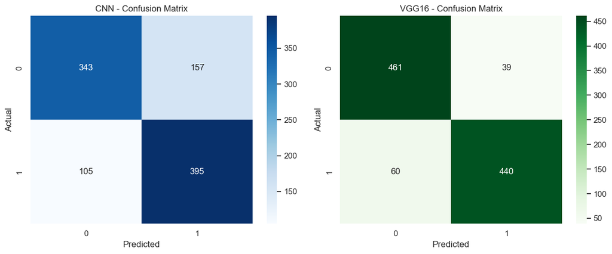

```python
# Confusion Matrix
fig, axs = plt.subplots(1, 2, figsize=(12, 5))
sns.heatmap(confusion_matrix(y_true, y_pred_cnn), annot=True, fmt='d', ax=axs[0], cmap='Blues')
axs[0].set_title("CNN - Confusion Matrix")
axs[0].set_xlabel("Predicted")
axs[0].set_ylabel("Actual")

sns.heatmap(confusion_matrix(y_true, y_pred_vgg), annot=True, fmt='d', ax=axs[1], cmap='Greens')
axs[1].set_title("VGG16 - Confusion Matrix")
axs[1].set_xlabel("Predicted")
axs[1].set_ylabel("Actual")

plt.tight_layout()
plt.show()
```

### 4.3. precision, recall, F1-score,

```python
print("4.3 Classification Report: CNN\n")
print(classification_report(y_true, y_pred_cnn, target_names=["Cat", "Dog"]))

print("\n4.3 Classification Report: VGG16\n")
print(classification_report(y_true, y_pred_vgg, target_names=["Cat", "Dog"]))
```

```
4.3 Classification Report: CNN

              precision    recall  f1-score   support

         Cat       0.77      0.69      0.72       500
         Dog       0.72      0.79      0.75       500

    accuracy                           0.74      1000
   macro avg       0.74      0.74      0.74      1000
weighted avg       0.74      0.74      0.74      1000


4.3 Classification Report: VGG16

              precision    recall  f1-score   support

         Cat       0.88      0.92      0.90       500
         Dog       0.92      0.88      0.90       500

    accuracy                           0.90      1000
   macro avg       0.90      0.90      0.90      1000
weighted avg       0.90      0.90      0.90      1000
```

### 4.4. precision-recall curve.

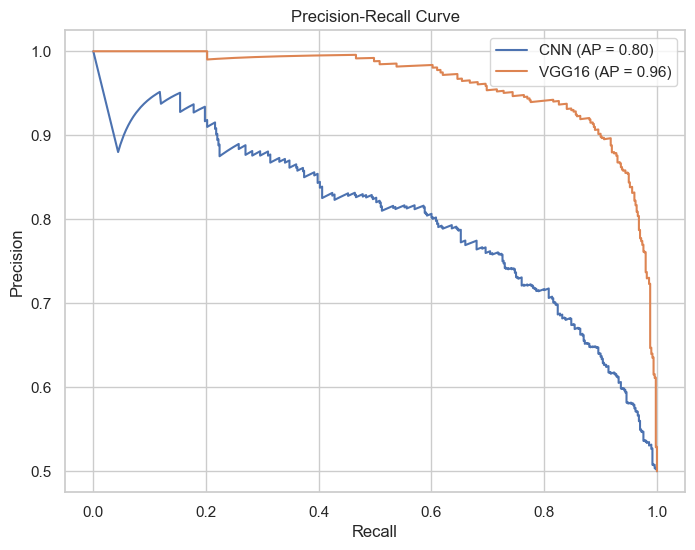

```python
# PR Curve
def plot_pr_curve(y_true, y_score, label):
    precision, recall, _ = precision_recall_curve(y_true, y_score)
    ap = average_precision_score(y_true, y_score)
    plt.plot(recall, precision, label=f"{label} (AP = {ap:.2f})")

plt.figure(figsize=(8, 6))
plot_pr_curve(y_true, cnn_preds, "CNN")
plot_pr_curve(y_true, vgg_preds, "VGG16")
plt.xlabel("Recall")
plt.ylabel("Precision")
plt.title("Precision-Recall Curve")
plt.legend()
plt.grid(True)
plt.show()
```

### 4.5 Explore specific examples in which the model failed to predict correctly.

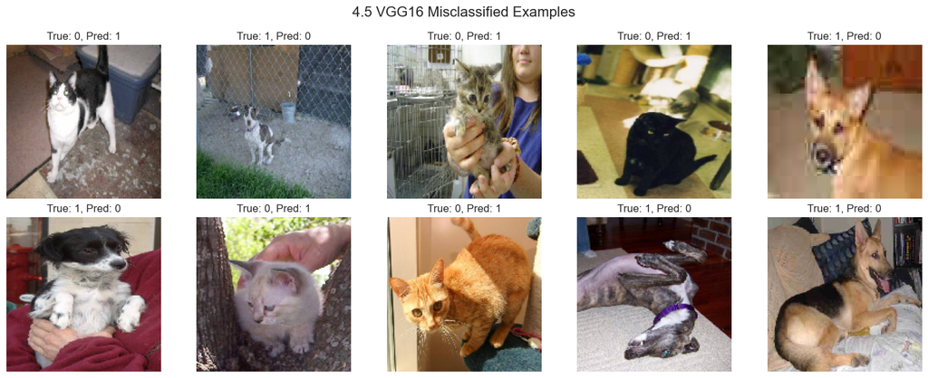

```python
from tensorflow.keras.utils import array_to_img

val_generator.reset()
misclassified_idx = np.where(y_pred_vgg != y_true)[0]

# Showing 10 random misclassified samples
plt.figure(figsize=(15, 6))
for i, idx in enumerate(np.random.choice(misclassified_idx, 10, replace=False)):
    batch_idx = idx // val_generator.batch_size
    img_batch, label_batch = val_generator[batch_idx]
    img = array_to_img(img_batch[idx % val_generator.batch_size])
    true = int(label_batch[idx % val_generator.batch_size])
    pred = int(vgg_preds[idx] > 0.5)

    plt.subplot(2, 5, i + 1)
    plt.imshow(img)
    plt.axis("off")
    plt.title(f"True: {true}, Pred: {pred}")
plt.suptitle("4.5 VGG16 Misclassified Examples", fontsize=16)
plt.tight_layout()
plt.show()
```

### 5. Add your conclusions. (3 point)

**Recommendations:**

- Fine-tune more VGG16 layers.
- Use data augmentation.
- Try stronger regularization or ResNet-based models.

**Insight:** Fine-tuning a pretrained network like VGG16 provides much better results than training a small custom CNN from scratch.